# Social Network Analysis

Worksheet 6: Network Visualization I

Author

Termeh Shafie

## Load Packages

```r
library(igraph)
library(graphlayouts)
library(ggraph)
library(networkdata)
```

## Prepare data

```r
# load the game of thrones dataset
data(got)
gotS1 <- got[[1]]
```

## Basic plotting

[figure not shown]

```r
plot(gotS1)
```

**Note**

This plot is not representative for the capabilities of igraph. Check out [this tutorial](https://kateto.net/netscix2016.html)

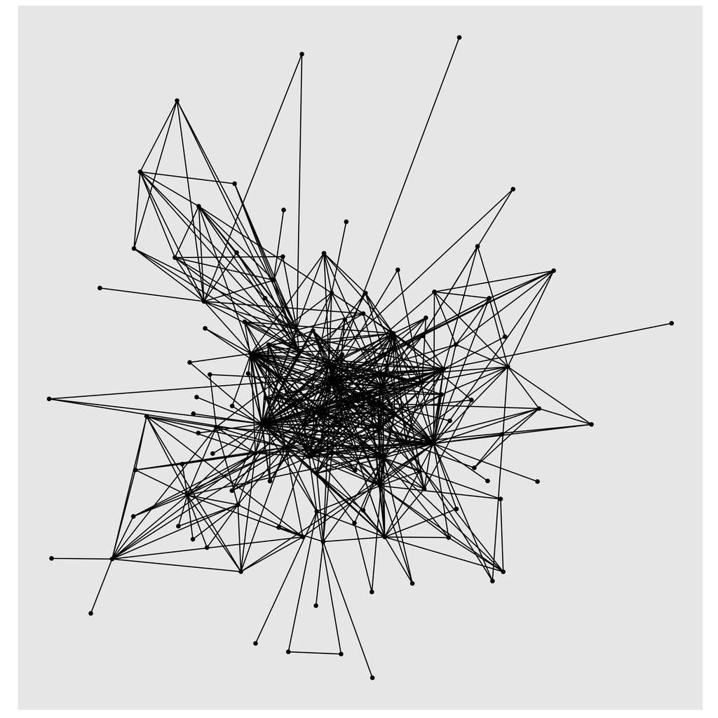

```r
# quick plot function of ggraph
autograph(gotS1)
```

`autograph()` allows you to specify node/edge colours too but it really is only meant to give you a quick overview without writing a massive amount of code. Think of it as the `plot()` function for `ggraph`.

Before we continue, we add some more node attributes to the GoT network that can be used during visualization.

```r
# define a custom color palette
got_palette <- c(
  "#1A5878", "#C44237", "#AD8941", "#E99093",
  "#50594B", "#8968CD", "#9ACD32"
)

# compute a clustering for node colors
V(gotS1)$clu <- as.character(membership(cluster_louvain(gotS1)))

# compute degree as node size
V(gotS1)$size <- degree(gotS1)
```

### Aesthetics and scales examples

[figure not shown]

```r
ggraph(gotS1, layout = "stress") +
  geom_edge_link0(aes(edge_width = weight), edge_colour = "grey66") +
  geom_node_point(aes(fill = clu, size = size), shape = 21) +
  geom_node_text(aes(filter = (size >= 25), label = name), size = 6) +
  scale_fill_manual(values = got_palette) +
  scale_edge_width(range = c(0.2, 3)) +
  scale_size(range = c(3, 12)) +
  theme_graph() +
  theme(legend.position = "none")+
  coord_fixed()
```

Using geom_edge_link instead of geom_edge_link0 for gradients along edges

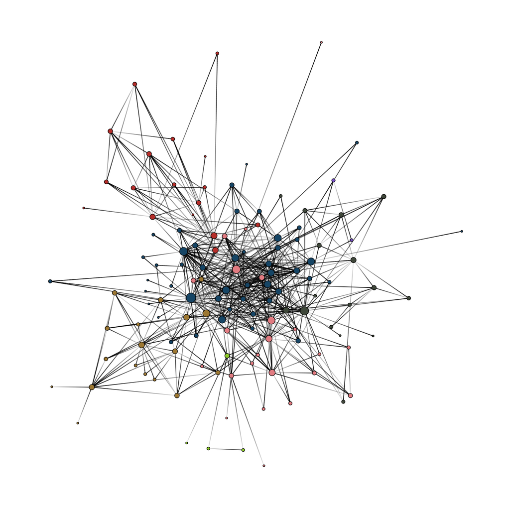

```r
ggraph(gotS1, layout = "stress") +
  geom_edge_link(aes(alpha = after_stat(index)), edge_colour = "black") +
  geom_node_point(aes(fill = clu, size = size), shape = 21) +
  scale_fill_manual(values = got_palette) +
  scale_edge_width_continuous(range = c(0.2, 3)) +
  scale_size_continuous(range = c(1, 6)) +
  theme_graph() +
  theme(legend.position = "none")+
  coord_fixed()
```

Using geom_edge_link2 instead of geom_edge_link0 for more advanced gradients along edges

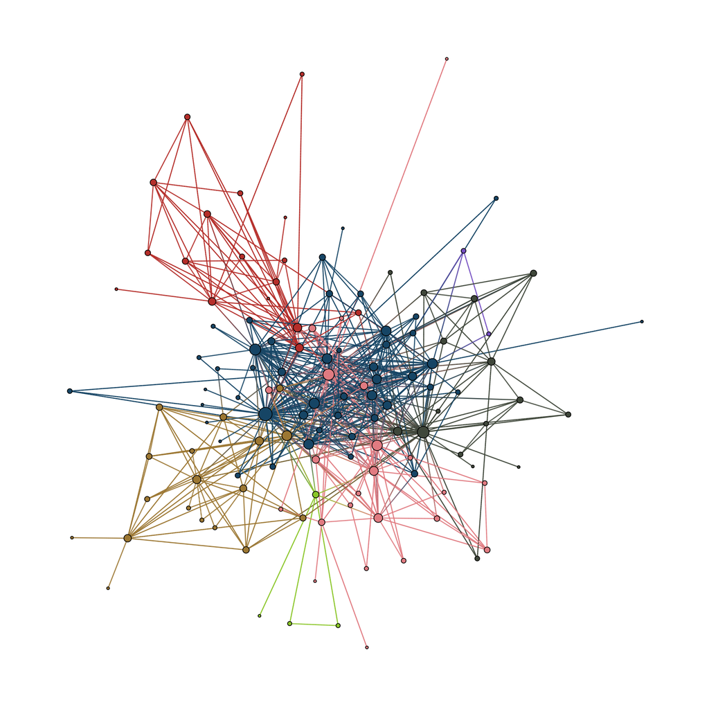

```r
ggraph(gotS1, layout = "stress") +
  geom_edge_link2(aes(edge_colour = node.clu),edge_width = 0.5)+
  geom_node_point(aes(fill = clu, size = size), shape = 21) +
  scale_fill_manual(values = got_palette) +
  scale_edge_color_manual(values = got_palette) +
  scale_edge_width_continuous(range = c(0.2, 3)) +
  scale_size_continuous(range = c(1, 6)) +
  theme_graph() +
  theme(legend.position = "none")+
  coord_fixed()
```

Using a different geom

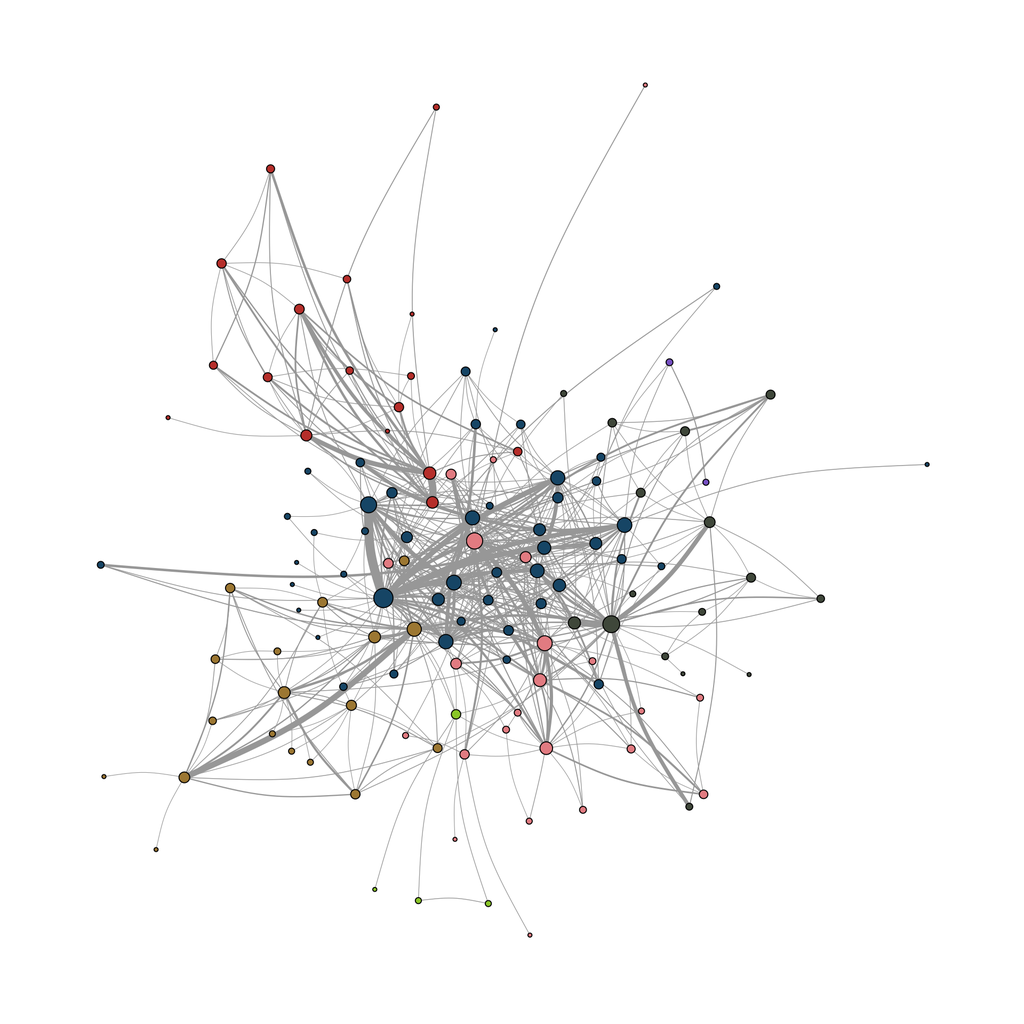

```r
ggraph(gotS1, layout = "stress") +
  geom_edge_arc0(aes(edge_width = weight), edge_colour = "grey66",strength = 0.1) +
  geom_node_point(aes(fill = clu, size = size), shape = 21) +
  scale_fill_manual(values = got_palette) +
  scale_edge_width(range = c(0.2, 3)) +
  scale_size(range = c(1, 6)) +
  theme_graph() +
  theme(legend.position = "none")+
  coord_fixed()
```

Not specifying any scales:

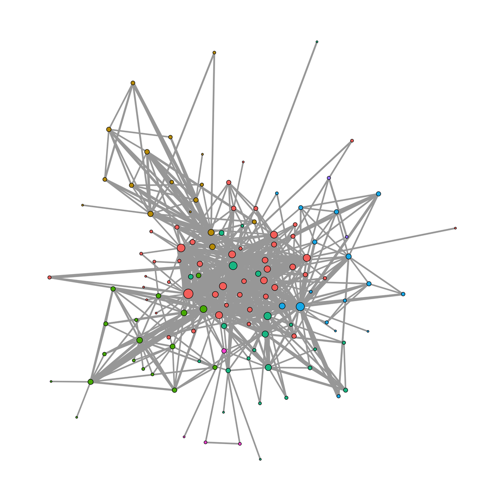

```r
ggraph(gotS1, layout = "stress") +
  geom_edge_link0(aes(edge_width = weight), edge_colour = "grey66") +
  geom_node_point(aes(fill = clu, size = size), shape = 21) +
  theme_graph() +
  theme(legend.position = "none")+
  coord_fixed()
```

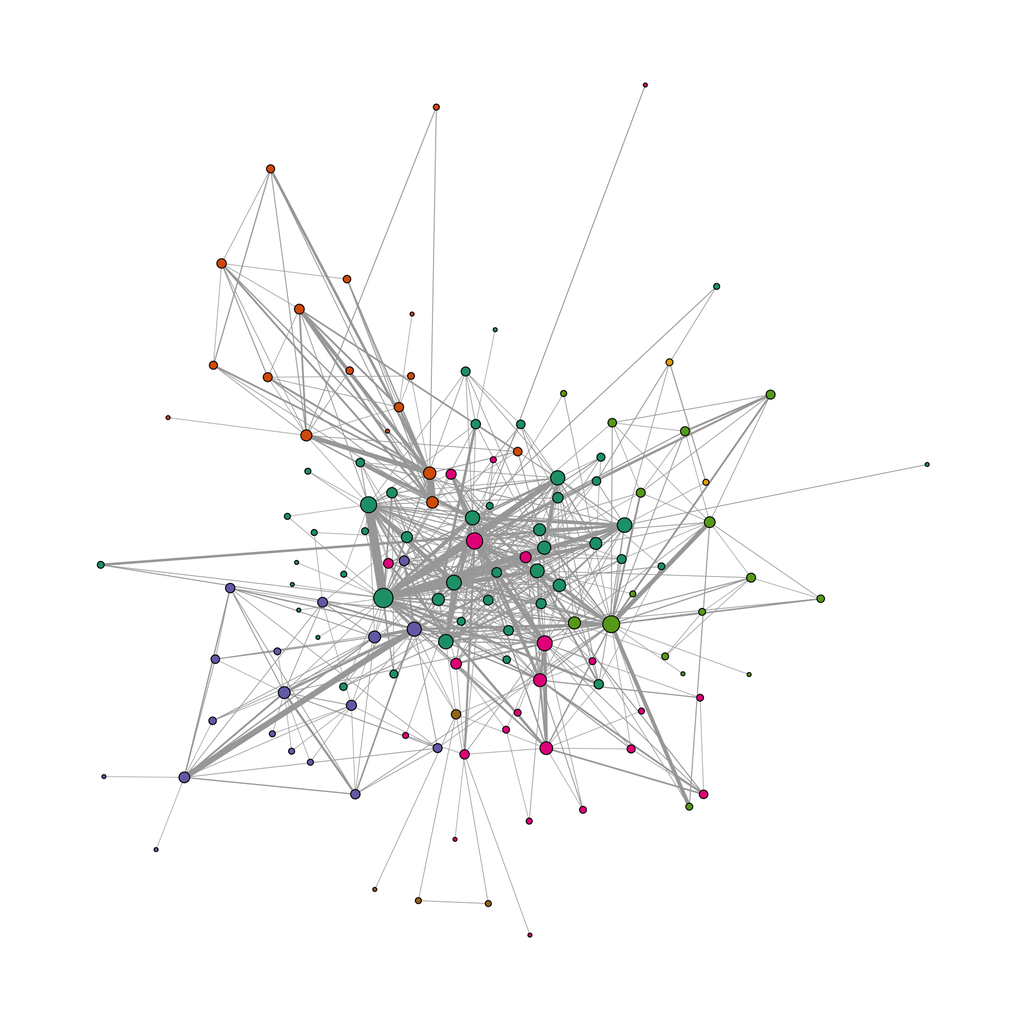

```r
ggraph(gotS1, layout = "stress") +
  geom_edge_link0(aes(edge_width = weight), edge_colour = "grey66") +
  geom_node_point(aes(fill = clu, size = size), shape = 21) +
  scale_fill_brewer(palette = "Dark2") +
  scale_edge_width_continuous(range = c(0.2, 3)) +
  scale_size_continuous(range = c(1, 6)) +
  theme_graph() +
  theme(legend.position = "none")+
  coord_fixed()
```

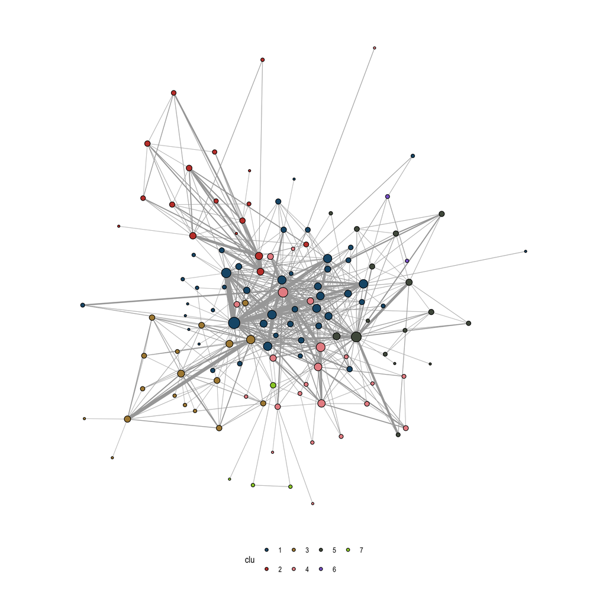

```r
ggraph(gotS1, layout = "stress") +
  geom_edge_link0(aes(edge_width = weight), edge_colour = "grey66") +
  geom_node_point(aes(fill = clu, size = size), shape = 21) +
  scale_fill_manual(values = got_palette) +
  scale_edge_width_continuous(range = c(0.2, 3), guide = "none") +
  scale_size_continuous(range = c(1, 6), guide = "none") +
  theme_graph() +
  theme(legend.position = "bottom") +
  coord_fixed()
```

## Contentric layouts

Plot that focuses on Ned Stark:

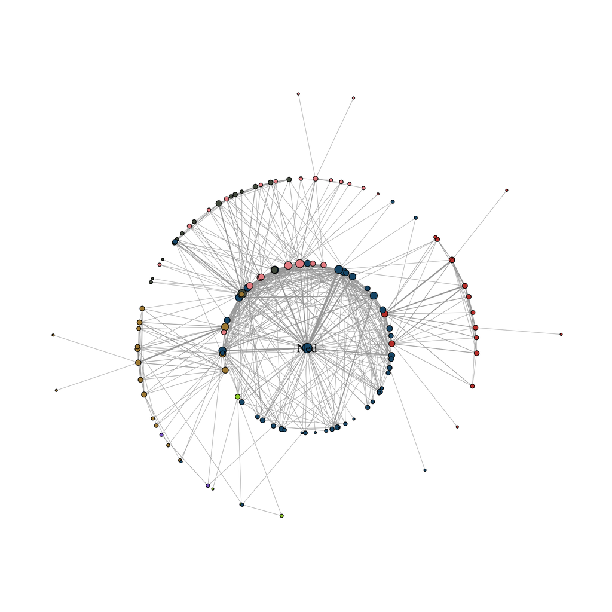

```r
ggraph(gotS1, layout = "focus", focus = 1) +
  geom_edge_link0(aes(edge_width = weight), edge_colour = "grey66") +
  geom_node_point(aes(fill = clu, size = size), shape = 21) +
  geom_node_text(aes(filter = (name == "Ned"), size = size, label = name),
    family = "serif"
  ) +
  scale_edge_width_continuous(range = c(0.2, 1.2)) +
  scale_size_continuous(range = c(1, 5)) +
  scale_fill_manual(values = got_palette) +
  theme_graph() +
  theme(legend.position = "none") +
  coord_fixed()
```

Adding `draw_circle`:

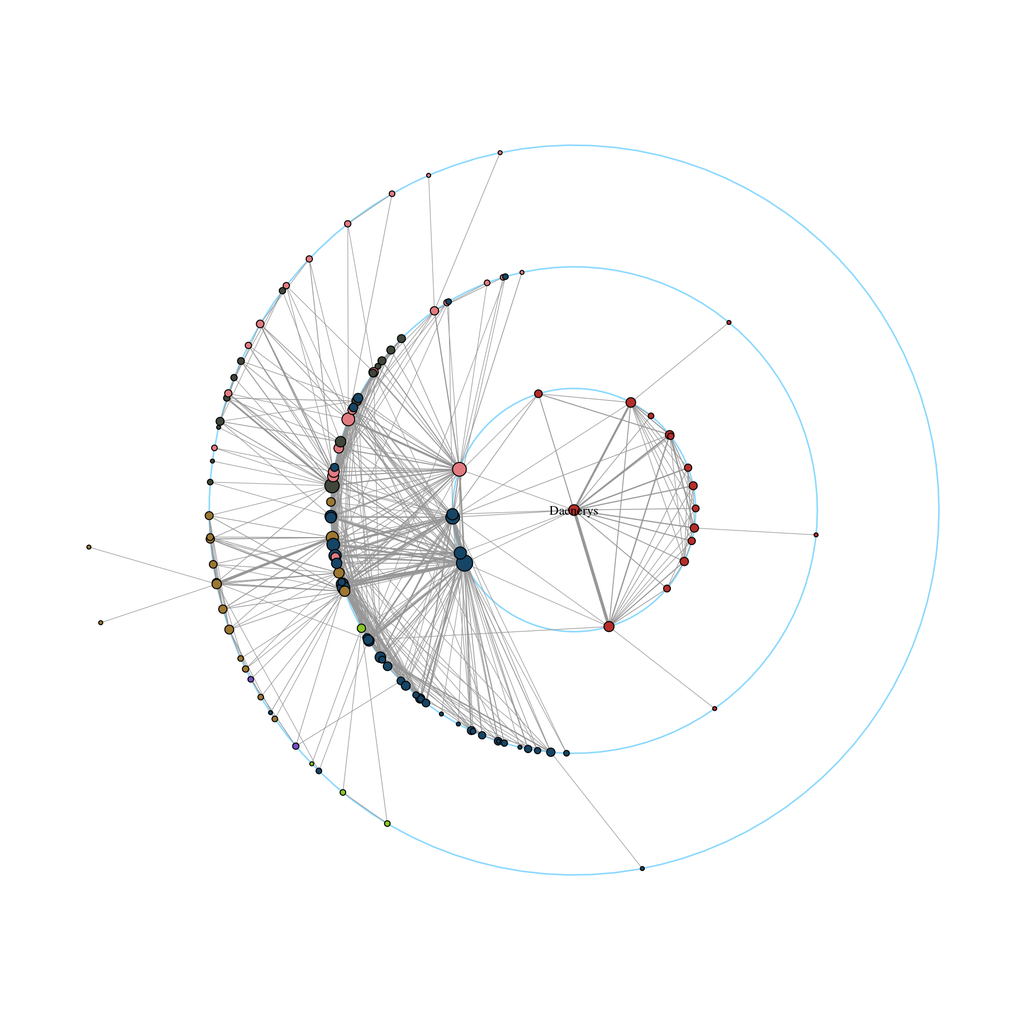

```r
ggraph(gotS1, layout = "focus", focus = 2) +
  draw_circle(col = "#00BFFF", use = "focus", max.circle = 3) +
  geom_edge_link0(aes(width = weight), edge_colour = "grey66") +
  geom_node_point(aes(fill = clu, size = size), shape = 21) +
  geom_node_text(aes(filter = (name == "Daenerys"), size = size, label = name),
    family = "serif"
  ) +
  scale_edge_width_continuous(range = c(0.2, 1.2)) +
  scale_size_continuous(range = c(1, 5)) +
  scale_fill_manual(values = got_palette) +
  theme_graph() +
  theme(legend.position = "none") +
  coord_fixed()
```

Concentric layout based on a centrality index:

[figure not shown]

```r
ggraph(gotS1, layout = "centrality", cent = strength(gotS1)) +
  geom_edge_link0(aes(edge_width = weight), edge_colour = "grey66") +
  geom_node_point(aes(fill = clu, size = size), shape = 21) +
  geom_node_text(aes(size = size, label = name), family = "serif") +
  scale_edge_width_continuous(range = c(0.2, 0.9)) +
  scale_size_continuous(range = c(1, 8)) +
  scale_fill_manual(values = got_palette) +
  theme_graph() +
  theme(legend.position = "none") +
  coord_fixed()
```

## Exercise 1

Use the network of a different season to produce a plot by yourself  
OR choose a dataset from the networkdata package `data(package = "networkdata")`

There are no constrains, just try out and play around

## Exercise 2

Recreate the iconic “polblogs” network visualization

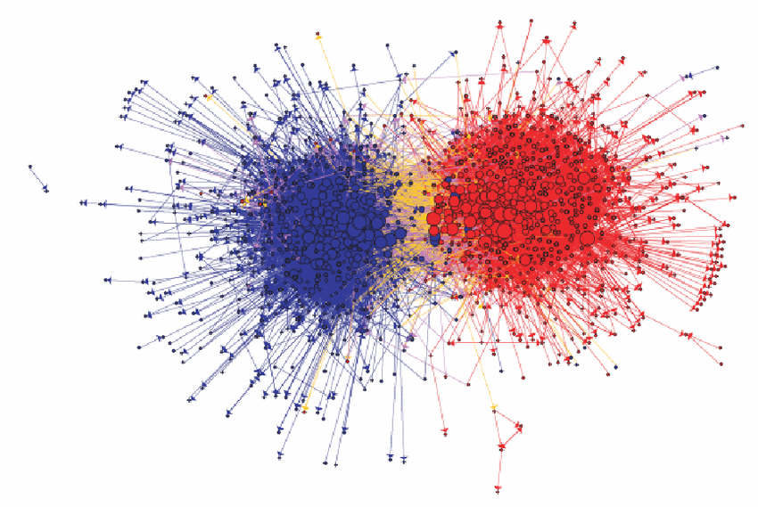

The network shows the linking between political blogs during the 2004 election in the US. Red nodes are conservative leaning blogs and blue ones liberal.

```r
data("polblogs")
```